# Task 1: Libraries and Importing the dataset

Load your libraries in a single block Document what each library does any why you need it. Also be sure to document what libraries are and why we need to import them.

Import your data Explain what a data frame is.

```python
# Importing necessary libraries

# Pandas for data manipulation and analysis.
# It provides data structures such as DataFrames which make it easy to work with structured data.
import pandas as pd

# Numpy for numerical computations.
# Useful for handling arrays and performing fast mathematical computations on large datasets.
import numpy as np

# Matplotlib for creating static, interactive, and animated visualizations in Python.
# Important for EDA to help us understand the data distribution through various visuals.
import matplotlib.pyplot as plt

# Seaborn for statistical data visualization.
# Builds upon Matplotlib and provides a high-level interface for visually appealing and informative statistical graphics.
import seaborn as sns

# Scikit-learn (sklearn) for machine learning and data preprocessing.
# Contains modules and functions for model training, data preprocessing, and evaluation. LabelEncoder and StandardScaler help encode categorical data and scaling numerical data for modeling.
from sklearn.model_selection import train_test_split
from sklearn.preprocessing import LabelEncoder, StandardScaler

# Suppressing warnings for cleaner output
import warnings
warnings.filterwarnings("ignore")

# Loading the dataset
url = "https://raw.githubusercontent.com/matthewpecsok/4482_fall_2024/main/data/census.csv"
df = pd.read_csv(url)

# Display the first five rows of the dataset to confirm successful load
df.head()
```

|  | age | workclass | fnlwgt | education | education-num | marital-status | occupation | relationship | race | sex | capital-gain | capital-loss | hours-per-week | native-country | y |
| --- | --- | --- | --- | --- | --- | --- | --- | --- | --- | --- | --- | --- | --- | --- | --- |
| 0 | 39 | State-gov | 77516 | Bachelors | 13 | Never-married | Adm-clerical | Not-in-family | White | Male | 2174 | 0 | 40 | United-States | <=50K |
| 1 | 50 | Self-emp-not-inc | 83311 | Bachelors | 13 | Married-civ-spouse | Exec-managerial | Husband | White | Male | 0 | 0 | 13 | United-States | <=50K |
| 2 | 38 | Private | 215646 | HS-grad | 9 | Divorced | Handlers-cleaners | Not-in-family | White | Male | 0 | 0 | 40 | United-States | <=50K |
| 3 | 53 | Private | 234721 | 11th | 7 | Married-civ-spouse | Handlers-cleaners | Husband | Black | Male | 0 | 0 | 40 | United-States | <=50K |
| 4 | 28 | Private | 338409 | Bachelors | 13 | Married-civ-spouse | Prof-specialty | Wife | Black | Female | 0 | 0 | 40 | Cuba | <=50K |

# Task 2: High-level exploration of the dataset

In this block use the commands we have learned throughout the course to explore your dataset. This section is not intended to explore by the target variable, which will be done in a later section. This section is intended to be high level descriptives explaining the entire dataset (most/all columns not one or two columns at a time (ie df.describe() not df.somecol.value_counts()

Be thorough (use as many commands here as you can find when going back through the material).

```
<class 'pandas.core.frame.DataFrame'>
RangeIndex: 32561 entries, 0 to 32560
Data columns (total 15 columns):
 #   Column          Non-Null Count  Dtype
---  ------          --------------  -----
 0   age             32561 non-null  int64
 1   workclass       32561 non-null  object
 2   fnlwgt          32561 non-null  int64
 3   education       32561 non-null  object
 4   education-num   32561 non-null  int64
 5   marital-status  32561 non-null  object
 6   occupation      32561 non-null  object
 7   relationship    32561 non-null  object
 8   race            32561 non-null  object
 9   sex             32561 non-null  object
 10  capital-gain    32561 non-null  int64
 11  capital-loss    32561 non-null  int64
 12  hours-per-week  32561 non-null  int64
 13  native-country  32561 non-null  object
 14  y               32561 non-null  object
dtypes: int64(6), object(9)
memory usage: 3.7+ MB
Dataset shape: (32561, 15)
Missing values per column:
 age               0
workclass         0
fnlwgt            0
education         0
education-num     0
marital-status    0
occupation        0
relationship      0
race              0
sex               0
capital-gain      0
capital-loss      0
hours-per-week    0
native-country    0
y                 0
dtype: int64
```

[output cut: 23 more lines]

```
 'Other-service' 'Sales' 'Craft-repair' 'Transport-moving'
 'Farming-fishing' 'Machine-op-inspct' 'Tech-support' '?'
 'Protective-serv' 'Armed-Forces' 'Priv-house-serv']
Categories in relationship: ['Not-in-family' 'Husband' 'Wife' 'Own-child' 'Unmarried' 'Other-relative']
Categories in race: ['White' 'Black' 'Asian-Pac-Islander' 'Amer-Indian-Eskimo' 'Other']
Categories in sex: ['Male' 'Female']
Categories in native-country: ['United-States' 'Cuba' 'Jamaica' 'India' '?' 'Mexico' 'South'
 'Puerto-Rico' 'Honduras' 'England' 'Canada' 'Germany' 'Iran'
 'Philippines' 'Italy' 'Poland' 'Columbia' 'Cambodia' 'Thailand' 'Ecuador'
 'Laos' 'Taiwan' 'Haiti' 'Portugal' 'Dominican-Republic' 'El-Salvador'
 'France' 'Guatemala' 'China' 'Japan' 'Yugoslavia' 'Peru'
 'Outlying-US(Guam-USVI-etc)' 'Scotland' 'Trinadad&Tobago' 'Greece'
 'Nicaragua' 'Vietnam' 'Hong' 'Ireland' 'Hungary' 'Holand-Netherlands']
Categories in y: ['<=50K' '>50K']
Number of duplicate rows: 24
```

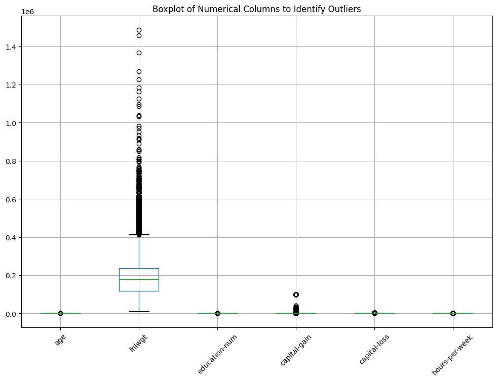

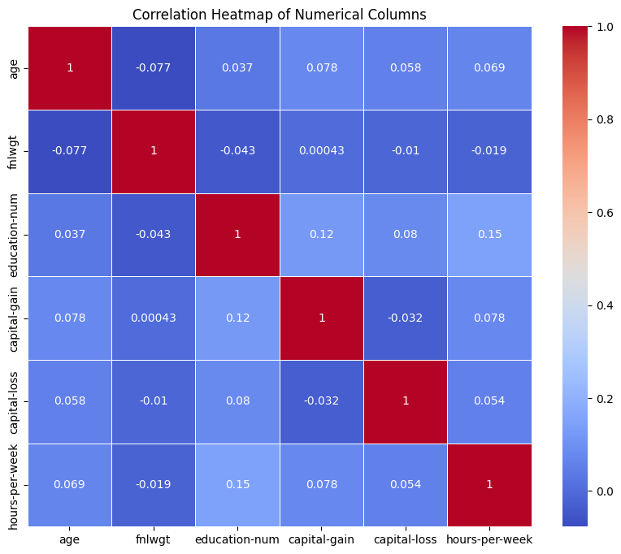

```python
# Displays basic information about the dataset, including column names, data types, and non-null counts
df.info()

# Displays the shape of the dataset (number of rows and columns)
print("Dataset shape:", df.shape)

# Displays the first five rows of the dataset to get a feel of what the data looks like
df.head()
# Displays the last five rows of the dataset to see if there are any anomalies or discrepancies at the end
df.tail()

# Computes descriptive statistics for numerical columns to get an overview of central tendency, dispersion, and shape of the data's distribution
df.describe()

# Computes descriptive statistics for categorical columns to see unique values and frequencies
df.describe(include=['object'])

# Checks for missing values in each column to identify any potential data quality issues that would otherwise effect the data exploration
print("Missing values per column:\n", df.isnull().sum())

# Identifies unique values in each column to understand the variety within each feature
for column in df.columns:
    unique_vals = df[column].nunique()
    print(f"Unique values in {column}: {unique_vals}")

# Displays the number of unique categories per column for categorical features
categorical_columns = df.select_dtypes(include=['object']).columns
for column in categorical_columns:
    print(f"Categories in {column}:", df[column].unique())

# Checks for duplicated rows to understand if any data cleaning is required as we do not want redundancies in our data
print("Number of duplicate rows:", df.duplicated().sum())

# Checks for outliers in numerical data by plotting boxplots for each numerical column
import matplotlib.pyplot as plt
numerical_columns = df.select_dtypes(include=['number']).columns
plt.figure(figsize=(12, 8))
df[numerical_columns].boxplot()
plt.title("Boxplot of Numerical Columns to Identify Outliers")
plt.xticks(rotation=45)
plt.show()

# Examines correlations between numerical columns using a correlation heatmap
import seaborn as sns
plt.figure(figsize=(10, 8))
sns.heatmap(df[numerical_columns].corr(), annot=True, cmap='coolwarm', linewidths=0.5)
plt.title("Correlation Heatmap of Numerical Columns")
plt.show()
```

# Task 3: Column by column exploration

Excluding the target variable: For each column in the dataset use your analysis skills to explore the column using descriptive summaries and graphs. For each column after reading the exploration I should know what the data type is, what values are in the column, for categorical you should describe the counts, for continuous mean, median, standard deviation among possible others (that list is NOT comprehensive of what I would expect).

```
Exploration of 'age':
----------------------------------------
Data Type: int64
Mean: 38.58164675532078
Median: 37.0
Standard Deviation: 13.640432553581146
Minimum: 17
Maximum: 90
```

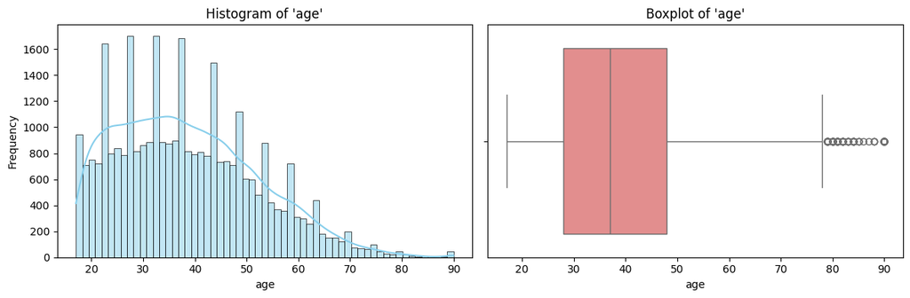

```
--------------------------------------------------

Exploration of 'workclass':
----------------------------------------
Data Type: object
Unique Values in 'workclass':
workclass
Private             22696
Self-emp-not-inc     2541
Local-gov            2093
?                    1836
State-gov            1298
Self-emp-inc         1116
Federal-gov           960
Without-pay            14
Never-worked            7
Name: count, dtype: int64
```

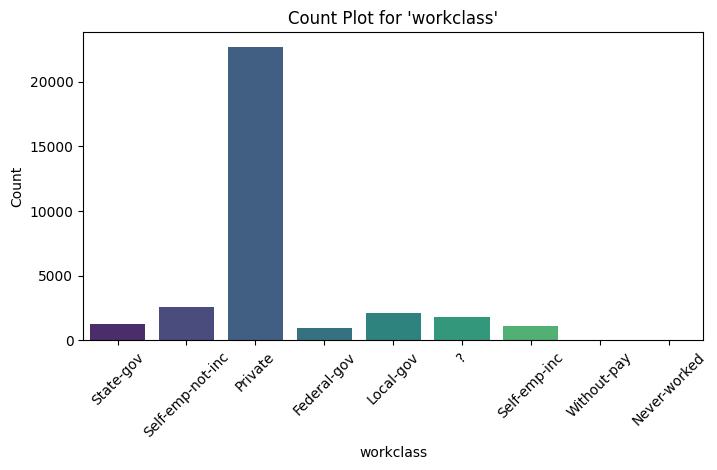

```
--------------------------------------------------

Exploration of 'fnlwgt':
----------------------------------------
Data Type: int64
Mean: 189778.36651208502
Median: 178356.0
Standard Deviation: 105549.97769702233
Minimum: 12285
Maximum: 1484705
```

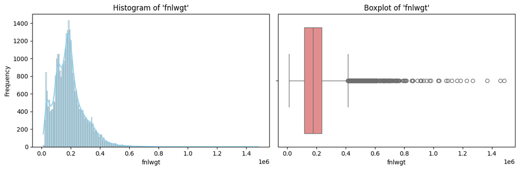

```
--------------------------------------------------

Exploration of 'education':
----------------------------------------
Data Type: object
Unique Values in 'education':
education
HS-grad         10501
Some-college     7291
Bachelors        5355
Masters          1723
Assoc-voc        1382
11th             1175
Assoc-acdm       1067
10th              933
7th-8th           646
Prof-school       576
9th               514
12th              433
Doctorate         413
5th-6th           333
1st-4th           168
Preschool          51
Name: count, dtype: int64
```

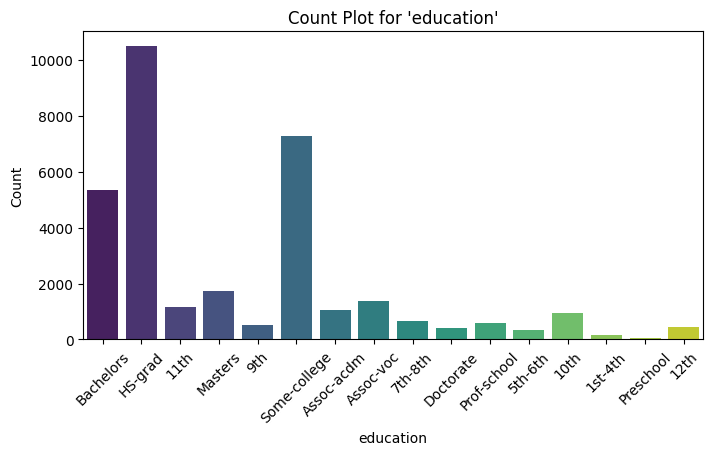

```
--------------------------------------------------

Exploration of 'education-num':
----------------------------------------
Data Type: int64
Mean: 10.0806793403151
Median: 10.0
Standard Deviation: 2.5727203320673406
Minimum: 1
Maximum: 16
```

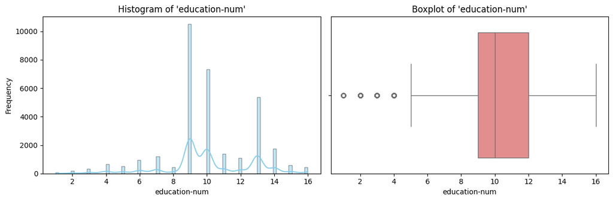

```
--------------------------------------------------

Exploration of 'marital-status':
----------------------------------------
Data Type: object
Unique Values in 'marital-status':
marital-status
Married-civ-spouse       14976
Never-married            10683
Divorced                  4443
Separated                 1025
Widowed                    993
Married-spouse-absent      418
Married-AF-spouse           23
Name: count, dtype: int64
```

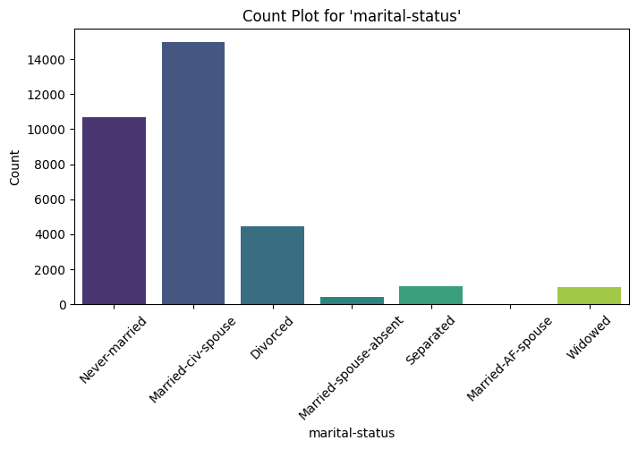

```
--------------------------------------------------

Exploration of 'occupation':
----------------------------------------
Data Type: object
Unique Values in 'occupation':
occupation
Prof-specialty       4140
Craft-repair         4099
Exec-managerial      4066
Adm-clerical         3770
Sales                3650
Other-service        3295
Machine-op-inspct    2002
?                    1843
Transport-moving     1597
Handlers-cleaners    1370
Farming-fishing       994
Tech-support          928
Protective-serv       649
Priv-house-serv       149
Armed-Forces            9
Name: count, dtype: int64
```

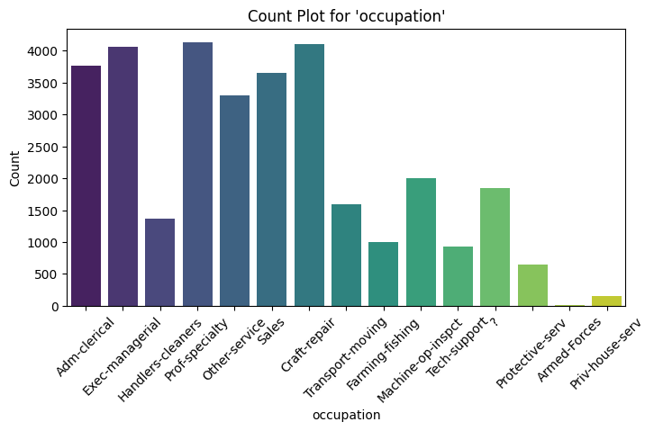

```
--------------------------------------------------

Exploration of 'relationship':
----------------------------------------
Data Type: object
Unique Values in 'relationship':
relationship
Husband           13193
Not-in-family      8305
Own-child          5068
Unmarried          3446
Wife               1568
Other-relative      981
Name: count, dtype: int64
```

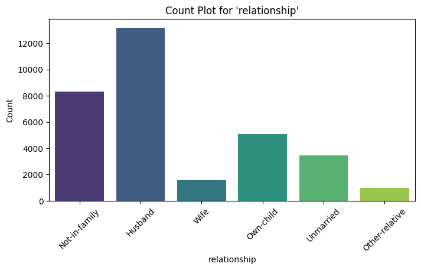

```
--------------------------------------------------

Exploration of 'race':
----------------------------------------
Data Type: object
Unique Values in 'race':
race
White                 27816
Black                  3124
Asian-Pac-Islander     1039
Amer-Indian-Eskimo      311
Other                   271
Name: count, dtype: int64
```

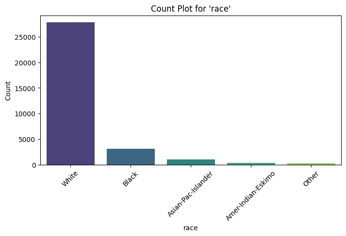

```
--------------------------------------------------

Exploration of 'sex':
----------------------------------------
Data Type: object
Unique Values in 'sex':
sex
Male      21790
Female    10771
Name: count, dtype: int64
```

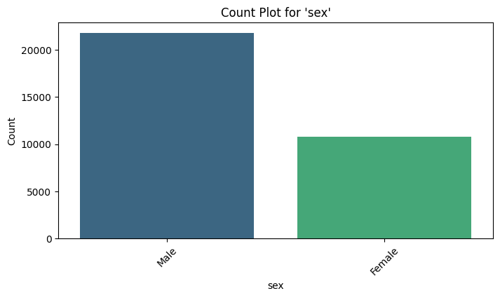

```
--------------------------------------------------

Exploration of 'capital-gain':
----------------------------------------
Data Type: int64
Mean: 1077.6488437087312
Median: 0.0
Standard Deviation: 7385.292084839299
Minimum: 0
Maximum: 99999
```

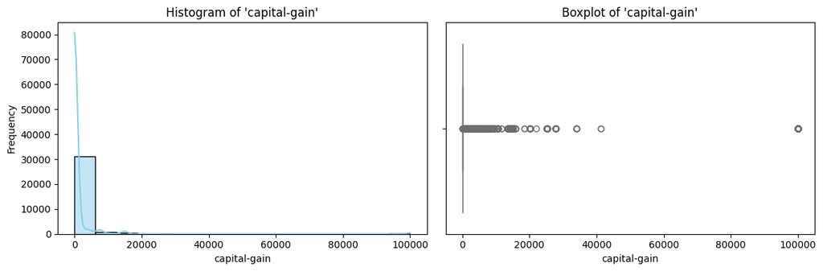

```
--------------------------------------------------

Exploration of 'capital-loss':
----------------------------------------
Data Type: int64
Mean: 87.303829734959
Median: 0.0
Standard Deviation: 402.960218649059
Minimum: 0
Maximum: 4356
```

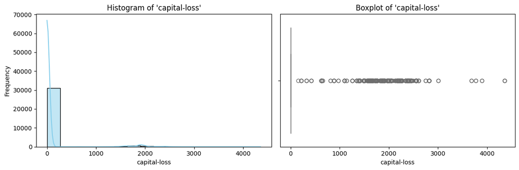

```
--------------------------------------------------

Exploration of 'hours-per-week':
----------------------------------------
Data Type: int64
Mean: 40.437455852092995
Median: 40.0
Standard Deviation: 12.34742868173081
Minimum: 1
Maximum: 99
```

[2 more figures not shown]

```python
import matplotlib.pyplot as plt
import seaborn as sns

# Column-by-column exploration

# Specifies the list of columns, excluding the target variable
columns_to_explore = [col for col in df.columns if col != 'y']

# This will loop through each column and apply appropriate exploration techniques
for column in columns_to_explore:
    print(f"Exploration of '{column}':")
    print("-" * 40)

    # Gets the data type of the column
    dtype = df[column].dtype
    print(f"Data Type: {dtype}")

    # Perform this if the column is categorical
    if dtype == 'object':
        # This will print unique values and counts
        print(f"Unique Values in '{column}':\n{df[column].value_counts()}\n")

        # Plots a bar plot for categorical features
        plt.figure(figsize=(8, 4))
        sns.countplot(data=df, x=column, palette="viridis")
        plt.title(f"Count Plot for '{column}'")
        plt.xlabel(column)
        plt.ylabel("Count")
        plt.xticks(rotation=45)
        plt.show()

    # If the column is numerical (continuous or discrete)
    else:
        # then their descriptive statistics will be calculated
        mean = df[column].mean()
        median = df[column].median()
        std_dev = df[column].std()
        min_val = df[column].min()
        max_val = df[column].max()

        print(f"Mean: {mean}")
        print(f"Median: {median}")
        print(f"Standard Deviation: {std_dev}")
        print(f"Minimum: {min_val}")
        print(f"Maximum: {max_val}")

        # Plots histogram and boxplot for numerical features
        fig, axes = plt.subplots(1, 2, figsize=(12, 4))

        # Histogram
        sns.histplot(df[column], kde=True, ax=axes[0], color='skyblue')
        axes[0].set_title(f"Histogram of '{column}'")
        axes[0].set_xlabel(column)
        axes[0].set_ylabel("Frequency")

        # Boxplot
        sns.boxplot(data=df, x=column, ax=axes[1], color='lightcoral')
        axes[1].set_title(f"Boxplot of '{column}'")
        axes[1].set_xlabel(column)

        plt.tight_layout()
        plt.show()

    print("\n" + "-"*50 + "\n")
```

# Task 4: Target Variable Exploration

Replicating some of the similar exploration techniques utilized in Task 3 for categorical variables explore your target variable. In this section make sure to document your code.

```
Exploration of Target Variable 'y':
----------------------------------------
Unique Values in 'y':
y
<=50K    24720
>50K      7841
Name: count, dtype: int64
```

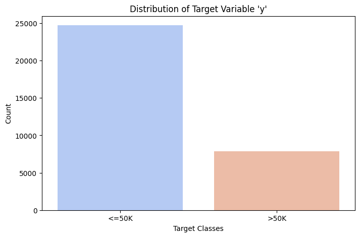

```python
# Target Variable Exploration for 'y'
target_column = 'y'

# Will display the unique values and their counts for 'y'
print(f"Exploration of Target Variable '{target_column}':")
print("-" * 40)
print(f"Unique Values in '{target_column}':\n{df[target_column].value_counts()}\n")

# Plotting bar plot to visualize the distribution of the target variable
plt.figure(figsize=(8, 5))
sns.countplot(data=df, x=target_column, palette="coolwarm")
plt.title("Distribution of Target Variable 'y'")
plt.xlabel("Target Classes")
plt.ylabel("Count")
plt.show()
```

# Task 5: Target Exploration by Predictors

Use at least one technique to explore your target variable by each predictor. For example you might explore the target variable by gender showing the proportions of the target for each gender or you may choose to do a boxplot of a continuous predictor by the target to show.

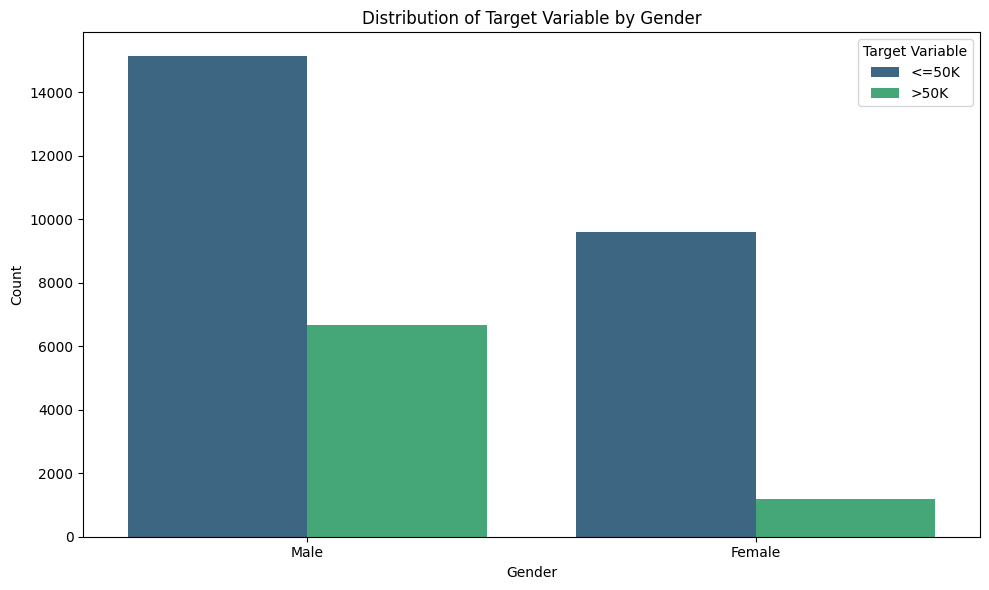

```python
import seaborn as sns
import matplotlib.pyplot as plt

# Bar plot categorical predictor for 'gender'
plt.figure(figsize=(10, 6))
sns.countplot(data=df, x='sex', hue='y', palette='viridis')
plt.title("Distribution of Target Variable by Gender")
plt.xlabel("Gender")
plt.ylabel("Count")
plt.legend(title='Target Variable')
plt.tight_layout()
plt.show()
```

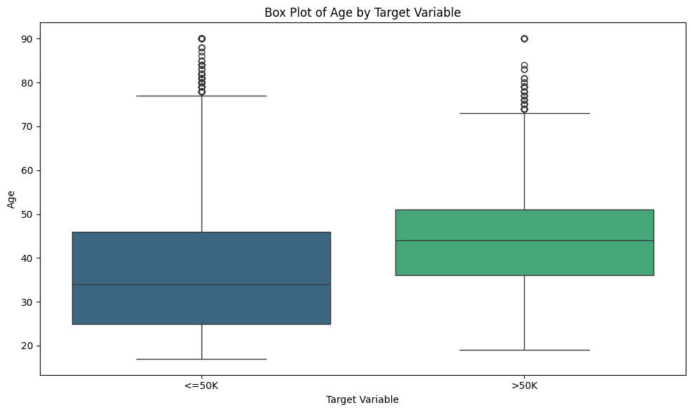

```python
# Box plot continuous predictor 'age'
plt.figure(figsize=(10, 6))
sns.boxplot(data=df, x='y', y='age', palette='viridis')
plt.title("Box Plot of Age by Target Variable")
plt.xlabel("Target Variable")
plt.ylabel("Age")
plt.tight_layout()
plt.show()
```

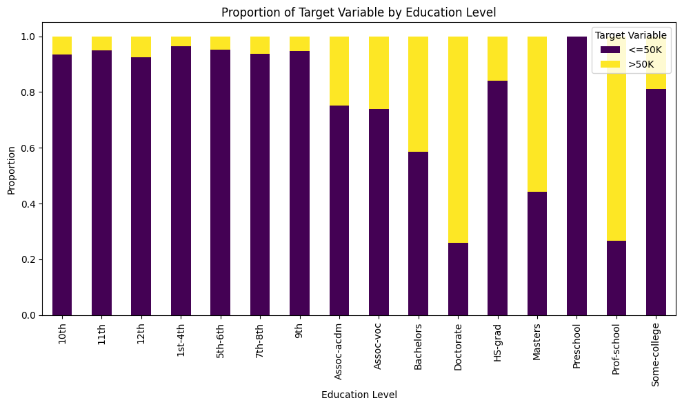

```python
# Cross tabulation for 'education' and 'y'
pd.crosstab(df['education'], df['y'], normalize='index').plot(kind='bar', stacked=True, figsize=(10, 6), colormap="viridis")
plt.title("Proportion of Target Variable by Education Level")
plt.xlabel("Education Level")
plt.ylabel("Proportion")
plt.legend(title='Target Variable')
plt.tight_layout()
plt.show()
```

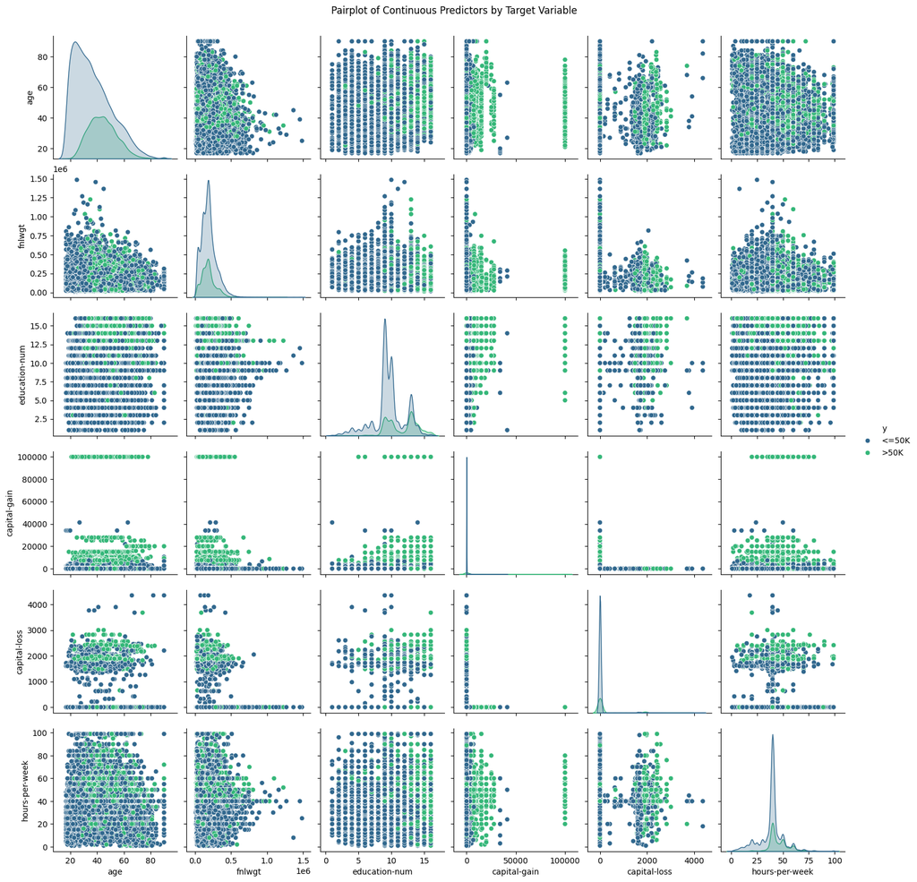

```python
# Pairplot for continuous predictors with target variable as hue
sns.pairplot(df, hue='y', palette='viridis', diag_kind='kde')
plt.suptitle("Pairplot of Continuous Predictors by Target Variable", y=1.02)
plt.show()
```

# Task 6: Data Encoding

Pop the target variable. If necessary encode the target variable. In a text block make a column by column explanation for one-hot encoding your predictor dataframe. Get your dataframe shape. Then encode the dataframe. Describe the difference pre and post encoding of the dataframe. How has the shape changed?

```python
# Separating the target variable
target = df.pop('y')
```

```python
# Encode the target variable
from sklearn.preprocessing import LabelEncoder

label_encoder = LabelEncoder()
target_encoded = label_encoder.fit_transform(target)
```

Column by Column Explanation for One-Hot Coding:

It is important to utilize one-hot encoding in order to convert categorical columns with multiple categories into separate binary columns (0 or 1) for each category. This allows machine learning algorithms to interpret categorical data as numerical values, which is necessary for data processing.

Column-by-Column Explanation for One-Hot Encoding

The following are columns in the dataframe that contain categorical data that need to be converted in to numerical data (binary) through one-hot encoding.

[output not shown]

```python
# One-hot encode the predictor dataframe
df_encoded = pd.get_dummies(df, drop_first=True)
```

```python
# shows the shape of dataframe before and after encoding
print("Original DataFrame Shape:", df.shape)
print("Encoded DataFrame Shape:", df_encoded.shape)
```

```
Original DataFrame Shape: (32561, 14)
Encoded DataFrame Shape: (32561, 100)
```

Difference Pre and Post Encoding:

Pre: In the pre-encoding dataframe, categorical columns were represented with a single column per feature, even if they contained multiple categories (e.g., “gender” had only one column for both “Male” and “Female”).

How has the shape changed?

Before encoding, the dataframe had fewer columns because each categorical column was represented by a single column, regardless of how many unique values (categories) it contained.

# Submission

```python
!cp "/content/drive/My Drive/Colab Notebooks/P1_Scott_William.ipynb" ./

# run the second shell command, jupyter nbconvert --to html "file name of the notebook"
# create html from ipynb

!jupyter nbconvert --to html "P1_Scott_William.ipynb"
```

```
[NbConvertApp] Converting notebook P1_Scott_William.ipynb to html
[NbConvertApp] WARNING | Alternative text is missing on 21 image(s).
[NbConvertApp] Writing 2862511 bytes to P1_Scott_William.html
```